# Math 120 Spring 2022 Homepage

Updated: 01 May, 2022

## Final Quiz

**Be sure you have access to a working computer.** Make sure you can log into Notebowl. Have a backup if you’re worried (library, computer lab, etc).

If Notebowl freezes up during the quiz, **REFRESH THE PAGE IMMEDIATELY**. I promise you won’t lose any work!

Topics: Hyp Tests and CIs!

- Hyp tests for mu, p, mu1-mu2, p1-p2, rho, GOF, Independence
- CIs for mu, p, mu1-mu2, p1-p2
- Error Types
- Critical values
- P-values
- Significance level
- Planning for sample size
- Connection btwn CI and Hyp Test

Practice Problems (**in order of importance**):

- **Old Quiz Questions!** Specifically: Q9-Q13
- **Old Practice Problems!** Specifically: Week 9 - 13

Practice for test for rho:

- In a dataset on length and weight of 14 rats, we calculate a correlation of 0.53. Does this provide strong evidence of a linear relationship between length and weight? (Partial solutions: t=2.165, .05<p-val<.1)

## Old Practice Problems

### Week 13

- 7.27 (not part a) (p275)
- 6.33 (p239)
- 6.37 (p245)

### Week 12

- 5.25 (p203)
- 5.29 (p204)
- 6.19ab (p225)
- 6.21, 6.23 (p226)
- 6.24

### Week 11

- 5.15, 5.17 (p202)
- 5.21 (p203)
- 6.11a, 6.13 (p216)
- 7.1, 7.3 (note: p-vals are 2-tail) (p259)
- 7.7 (p260)
- 7.10, 7.11 (p261)

### Week 10

- 5.7 (p187)
- 5.11 (p188)
- 5.13 (p188)
- 6.15 (p216)
- The admissions office want to estimate the mean IQ of DU students. They take a sample of 50 DU students, and find their mean IQ to be 108.3. Construct a 90% confidence interval for the mean IQ of all DU students. You may use sigma = 15.
- Suppose the admissions office wants a 99% CI with error no greater than 2. How many students must they sample?

Answers (don’t look!): (104.8, 111.8), n=373

### Week 9

- Suppose the amount of time it takes students in a large math class to finish a quiz follows a normal distribution with mean 14 min, stdev 2.5 min.
1. What’s the probability it takes a student between 10 and 15 minutes?
2. How fast must a student finish in order to be in the bottom 1% of times?
3. If we take a sample of 10 students, what’s the probability that their average time taken is greater than 15 minutes?
4. If we take a sample of 40 students, how high must their mean time taken be in order to be in the top 10% (longest times) for such samples?
5. For which of the above (a-d) did we need to know in advance that finish times follow a normal distribution?

   **Answers** (Stop looking!!!): a) .6006 b) 8.18 min c) .1030 d) 14.506 e) All except d
- At DU, 77% of students are from out of state. If we take a sample of 100 students, what’s the probability that fewer than 75% of them are from out-of-state?

  **Answer** (Hey! Cut it out!!): .3156

### Week 8

- 4.1 (p142)
- 4.3 (a-g only) (p142)
- What’s the cutoff for the upper 15% of the z dist? (*Answer (don’t look yet! heystopityou’relooking!!!): 1.04*)
- What are the cutoffs for the middle 50% of the Z dist? (*Answer (don’t look yet! heystopityou’relooking!!!): -0.67, +0.67*)
- The amount of time it takes Prof Miller to walk to school varies uniformly between 8 and 10 minutes. Sketch the distribution, and compute the probabaility that it takes her at least 8.5 minutes. (*Answer(don’t look yet! heystopityou’relooking!!!): 75%* )

### Week 7

- 4.13 (p148)
- 4.14 (p148)
- 4.17 (p156)
- 4.19 (p156)
- 4.23 (p157)
- 4.31 (p165)

### Week 6

- 3.19 (p111) [Hint for b: first find out P(Passed)]
- 3.21 (p111)
- 3.31 (find probability distribution for winnings)
- 3.33 (p124)
- 3.35 (p124)
- 4.17 (p156)

### Week 5

- 3.1 (p92)
- 3.5c (p92)
- 3.7 [parts a, d, and f] (p93)
- 3.9 (p93)
- 3.10c (p93)
- 3.11 (p94)
- 3.13 (p109)
- 3.14 (p109)
- 3.15 (p109)
- In the table below about game night preferences: Are the events “poker” and “cookies” independent?

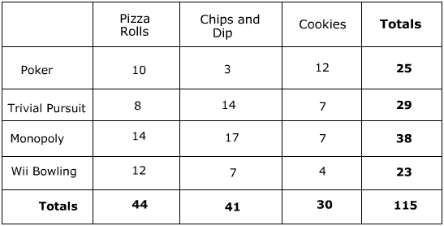

### Week 4

- 8.21 (p325)
- 8.23c (p326)
- 8.25c (p327)
- 8.27 (p330) [Specifically: would outlier strengthen/weaken/not affect correlation]
- 3.3 (p92)
- 3.5 (p92)
- 3.6 (p92)
- 3.7 (not a or f)

### Week 3

Reading: Texbook 8.1-2

Topics: Correlation, Scatterplots, r, least squares line, residuals, predictions

Practice Problems (from the textbook):

- 8.5 (p313)
- 8.7 (p314)
- 8.11 (p315)
- 8.13 (p316)
- 8.17 (p325)
- 8.19 (p325)
- **8.23** (all parts except c)

### Week 2

- 2.13 (p58)
- 2.15 (p58) [specifically about stdev/IQR]
- 2.16 (p59) [Hint: draw boxplots to answer questions]
- Practice Empirical Rule on Khan Academy [Click here](https://www.khanacademy.org/math/ap-statistics/density-curves-normal-distribution-ap/stats-normal-distributions/e/empirical_rule)

### Week 1

- 1.5 (19)
- 1.9 (p20)
- 1.10 (p20)
- 2.15 (p58) [Note: don’t worry about stdev/IQR]
- 2.16 (p59) [Note: don’t worry about stdev/IQR]

## HW Assignments

[Click Here for HW](https://millera2.github.io/Math-120-C/HW1.html)

## Office Hours

If you want to see me in person, I’m in my office (Fellows 212) **Wed 2:30pm-4pm.**

Or, you can catch me on Zoom by appointment. Don’t be shy! A few things:

- Schedule 24 hours in advance
- I’m free most weekdays from 2-4pm
- When you write, **propose a time** to cut down on back-and-forth.

I never check email after 4pm, so **don’t wait till the night before a deadline to get help!**

I like chatting with students – come find me!

## TA Hours

We have two excellent TAs - Ted and Eliza. Both are former students of mine. Go hang out with them. Hours:

Eliza: Monday 4-6pm

Ted: Sunday 4-7pm, Wednesday 4:30-6:30pm

All hours are held in **Olin 215**, just down the hall from our regular classroom.

## Shared Google Drive Folder:

[Click here for shared Google Drive folder](https://drive.google.com/drive/folders/1vE7OKbVElCvQqke3i_fL_dBgTuGcxHJa?usp=sharing)

## Textbook Links

- [Math 120 Textbook](https://www.openintro.org/book/os/)
  - *OpenIntro Statistics* is an excellent, free introduction to modern statistical analysis.